# SIM_CM1_G_M0724064

Luqmanda Haniffan_M0724064_G

2026-05-25

# Analisis Perilaku & Segmentasi Pelanggan

Database Sakila | Sistem Informasi Manajemen | Kelas G | Universitas Sebelas Maret

## Deskripsi Insight

#### Latar Belakang

Database **Sakila** merupakan database simulasi rental film yang disediakan oleh MySQL. Database ini merekam setiap aktivitas bisnis rental — mulai dari data pelanggan, koleksi film, transaksi penyewaan (*rental*), hingga pembayaran — sehingga kaya akan informasi yang dapat digali lebih dalam.

Salah satu aspek terpenting dalam bisnis rental film adalah **memahami perilaku pelanggan**: siapa pelanggan yang paling loyal, seberapa sering mereka menyewa, dan berapa besar nilai transaksi yang mereka hasilkan. Pemahaman ini dapat dijadikan dasar strategi pemasaran berbasis data (*data-driven marketing*).

Pada analisis ini diambil insight mengenai:

1. **Distribusi frekuensi rental per pelanggan** — seberapa sering setiap pelanggan menyewa film.
2. **Distribusi nilai total pembayaran per pelanggan** — siapa pelanggan bernilai tinggi.
3. **Segmentasi pelanggan menggunakan pendekatan RFM sederhana** — mengelompokkan pelanggan berdasarkan *Recency* (terakhir transaksi), *Frequency* (frekuensi rental), dan *Monetary* (total pembayaran).
4. **Pola waktu rental** — hari atau bulan apa transaksi rental paling ramai.
5. **Uji korelasi** antara frekuensi rental dan total pembayaran pelanggan.

## Connect Data SQL ke R

```r
library(DBI)
library(odbc)

# Cek driver yang tersedia
odbcListDrivers()
```

[output not shown]

[output cut: 61 more lines]

```r
# Koneksi awal (tanpa database)
DBI::dbConnect(odbc(),
               Driver = "MySQL ODBC 8.0 ANSI Driver",
               Server = "127.0.0.1",
               UID    = "root",
               PWD    = "Pemalang07_",
               Port   = 3306)
```

```
## <OdbcConnection> root@127.0.0.1 via TCP/IP
##   Database: null
##   MySQL Version: 8.0.43
```

```r
# Koneksi ke database Sakila
con1 <- DBI::dbConnect(odbc(),
                       Driver   = "MySQL ODBC 8.0 ANSI Driver",
                       Server   = "127.0.0.1",
                       UID      = "root",
                       PWD      = "Pemalang07_",
                       Port     = 3306,
                       Database = "sakila")
```

```r
# Menampilkan semua tabel yang tersedia
dbListTables(con1)
```

```
##  [1] "actor"                      "actor_info"
##  [3] "address"                    "category"
##  [5] "city"                       "country"
##  [7] "customer"                   "customer_list"
##  [9] "film"                       "film_actor"
## [11] "film_category"              "film_list"
## [13] "film_text"                  "inventory"
## [15] "language"                   "nicer_but_slower_film_list"
## [17] "payment"                    "rental"
## [19] "sales_by_film_category"     "sales_by_store"
## [21] "staff"                      "staff_list"
## [23] "store"
```

## Pengambilan Data

### Query 1 — Ringkasan Aktivitas per Pelanggan (RFM)

Query berikut mengambil tiga dimensi utama untuk setiap pelanggan: **Recency** (selisih hari sejak transaksi terakhir), **Frequency** (jumlah rental), dan **Monetary** (total pembayaran).

```r
query_rfm <- "
SELECT
    c.customer_id,
    CONCAT(c.first_name, ' ', c.last_name)     AS nama_pelanggan,
    c.store_id,
    COUNT(DISTINCT r.rental_id)                AS frequency,
    SUM(p.amount)                              AS monetary,
    MAX(r.rental_date)                         AS last_rental,
    DATEDIFF('2006-02-15', MAX(r.rental_date)) AS recency_hari
FROM customer c
JOIN rental  r ON c.customer_id = r.customer_id
JOIN payment p ON r.rental_id   = p.rental_id
GROUP BY c.customer_id, nama_pelanggan, c.store_id
ORDER BY monetary DESC
"

data_rfm <- dbGetQuery(con1, query_rfm)

data_rfm$frequency    <- as.numeric(data_rfm$frequency)
data_rfm$monetary     <- as.numeric(data_rfm$monetary)
data_rfm$recency_hari <- as.numeric(data_rfm$recency_hari)


data_rfm <- na.omit(data_rfm)

head(data_rfm, 10)
```

```
##    customer_id nama_pelanggan store_id frequency monetary         last_rental
## 1          526      KARL SEAL        2        45   221.55 2005-08-23 22:21:03
## 2          148   ELEANOR HUNT        1        46   216.54 2005-08-23 05:57:04
## 3          144     CLARA SHAW        1        42   195.58 2005-08-23 12:43:30
## 4          137 RHONDA KENNEDY        2        39   194.61 2005-08-23 21:56:04
## 5          178  MARION SNYDER        2        39   194.61 2006-02-14 15:16:03
## 6          459  TOMMY COLLAZO        1        38   186.62 2005-08-23 14:52:50
## 7          469    WESLEY BULL        2        40   177.60 2005-08-23 15:46:33
## 8          468       TIM CARY        1        39   175.61 2005-08-23 22:24:39
## 9          236    MARCIA DEAN        1        42   175.58 2006-02-14 15:16:03
## 10         181    ANA BRADLEY        2        34   174.66 2006-02-14 15:16:03
##    recency_hari
## 1           176
## 2           176
## 3           176
## 4           176
## 5             1
## 6           176
## 7           176
## 8           176
## 9             1
## 10            1
```

### Query 2 — Pola Waktu Rental (Bulanan)

```r
query_bulan <- "
SELECT
    MONTHNAME(rental_date) AS bulan,
    MONTH(rental_date)     AS no_bulan,
    COUNT(rental_id)       AS total_rental
FROM rental
GROUP BY bulan, no_bulan
ORDER BY no_bulan
"

data_bulan <- dbGetQuery(con1, query_bulan)

data_bulan$total_rental <- as.numeric(data_bulan$total_rental)
data_bulan$no_bulan     <- as.numeric(data_bulan$no_bulan)

data_bulan
```

```
##      bulan no_bulan total_rental
## 1 February        2          182
## 2      May        5         1156
## 3     June        6         2311
## 4     July        7         6709
## 5   August        8         5686
```

### Query 3 — Pola Waktu Rental (Per Hari dalam Seminggu)

```r
query_hari <- "
SELECT
    DAYNAME(rental_date)   AS hari,
    DAYOFWEEK(rental_date) AS no_hari,
    COUNT(rental_id)       AS total_rental
FROM rental
GROUP BY hari, no_hari
ORDER BY no_hari
"
data_hari <- dbGetQuery(con1, query_hari)

data_hari$total_rental <- as.numeric(data_hari$total_rental)
data_hari$no_hari      <- as.numeric(data_hari$no_hari)

data_hari
```

```
##        hari no_hari total_rental
## 1    Sunday       1         2320
## 2    Monday       2         2247
## 3   Tuesday       3         2463
## 4 Wednesday       4         2231
## 5  Thursday       5         2200
## 6    Friday       6         2272
## 7  Saturday       7         2311
```

### Query 4 — Top 20 Pelanggan Terproduktif

```r
query_top20 <- "
SELECT
    CONCAT(c.first_name, ' ', c.last_name) AS nama_pelanggan,
    COUNT(DISTINCT r.rental_id)            AS total_rental,
    SUM(p.amount)                          AS total_bayar
FROM customer c
JOIN rental  r ON c.customer_id = r.customer_id
JOIN payment p ON r.rental_id   = p.rental_id
GROUP BY c.customer_id, nama_pelanggan
ORDER BY total_bayar DESC
LIMIT 20
"

data_top20 <- dbGetQuery(con1, query_top20)


data_top20$total_rental <- as.numeric(data_top20$total_rental)
data_top20$total_bayar  <- as.numeric(data_top20$total_bayar)

data_top20
```

```
##    nama_pelanggan total_rental total_bayar
## 1       KARL SEAL           45      221.55
## 2    ELEANOR HUNT           46      216.54
## 3      CLARA SHAW           42      195.58
## 4   MARION SNYDER           39      194.61
## 5  RHONDA KENNEDY           39      194.61
## 6   TOMMY COLLAZO           38      186.62
## 7     WESLEY BULL           40      177.60
## 8        TIM CARY           39      175.61
## 9     MARCIA DEAN           42      175.58
## 10    ANA BRADLEY           34      174.66
## 11   JUNE CARROLL           37      173.63
## 12  DIANE COLLINS           35      169.65
## 13    LENA JENSEN           32      168.68
## 14  ARNOLD HAVENS           33      167.67
## 15    CURTIS IRBY           38      167.62
## 16       MIKE WAY           35      166.65
## 17    DAISY BATES           38      162.62
## 18  TONYA CHAPMAN           32      161.68
## 19    LOUIS LEONE           35      161.65
## 20  GORDON ALLARD           32      160.68
```

## Eksplorasi Data (EDA)

### Statistik Deskriptif

```r
cat("Statistik Deskriptif: Frequency (Jumlah Rental per Pelanggan) \n")
```

```
## Statistik Deskriptif: Frequency (Jumlah Rental per Pelanggan)
```

```r
summary(data_rfm$frequency)
```

```
##    Min. 1st Qu.  Median    Mean 3rd Qu.    Max.
##   12.00   23.00   26.00   26.78   30.00   46.00
```

```r
cat("\n Statistik Deskriptif: Monetary (Total Pembayaran per Pelanggan) \n")
```

```
##
##  Statistik Deskriptif: Monetary (Total Pembayaran per Pelanggan)
```

```r
summary(data_rfm$monetary)
```

```
##    Min. 1st Qu.  Median    Mean 3rd Qu.    Max.
##   50.85   94.78  110.73  112.53  128.71  221.55
```

```r
cat("\n Statistik Deskriptif: Recency (Hari sejak Transaksi Terakhir) \n")
```

```
##
##  Statistik Deskriptif: Recency (Hari sejak Transaksi Terakhir)
```

```r
summary(data_rfm$recency_hari)
```

```
##    Min. 1st Qu.  Median    Mean 3rd Qu.    Max.
##     1.0     1.0   176.0   130.2   177.0   182.0
```

```r
cat("\n Struktur Data RFM \n")
```

```
##
##  Struktur Data RFM
```

```r
str(data_rfm)
```

```
## 'data.frame':    599 obs. of  7 variables:
##  $ customer_id   : int  526 148 144 137 178 459 469 468 236 181 ...
##  $ nama_pelanggan: chr  "KARL SEAL" "ELEANOR HUNT" "CLARA SHAW" "RHONDA KENNEDY" ...
##  $ store_id      : int  2 1 1 2 2 1 2 1 1 2 ...
##  $ frequency     : num  45 46 42 39 39 38 40 39 42 34 ...
##  $ monetary      : num  222 217 196 195 195 ...
##  $ last_rental   : POSIXct, format: "2005-08-23 22:21:03" "2005-08-23 05:57:04" ...
##  $ recency_hari  : num  176 176 176 176 1 176 176 176 1 1 ...
```

## Visualisasi Data

### Visualisasi 1 — Distribusi Frekuensi Rental Pelanggan

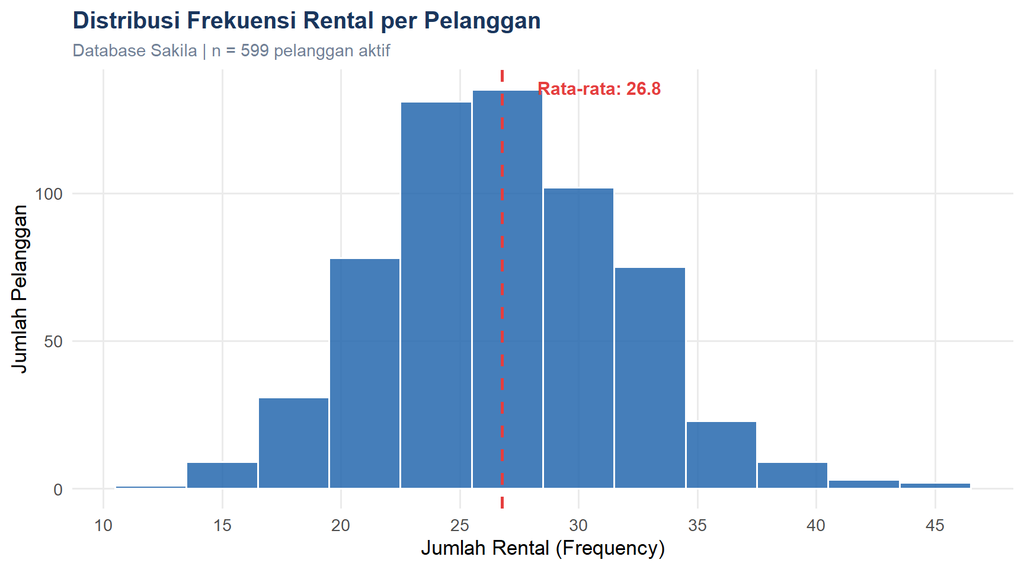

Histogram Distribusi Frekuensi Rental per Pelanggan

```r
ggplot(data_rfm, aes(x = frequency)) +
  geom_histogram(binwidth = 3, fill = "#2b6cb0", color = "#fff", alpha = 0.88) +
  geom_vline(xintercept = mean(data_rfm$frequency),
             color = "#e53e3e", linetype = "dashed", linewidth = 1) +
  annotate("text",
           x     = mean(data_rfm$frequency) + 1.5,
           y     = Inf,
           label = paste0("Rata-rata: ", round(mean(data_rfm$frequency), 1)),
           vjust = 1.8, hjust = 0,
           color = "#e53e3e", size = 4, fontface = "bold") +
  scale_x_continuous(breaks = seq(0, 50, 5)) +
  labs(
    title    = "Distribusi Frekuensi Rental per Pelanggan",
    subtitle = "Database Sakila | n = 599 pelanggan aktif",
    x        = "Jumlah Rental (Frequency)",
    y        = "Jumlah Pelanggan"
  ) +
  theme_minimal(base_size = 13) +
  theme(
    plot.title       = element_text(face = "bold", color = "#1a365d", size = 15),
    plot.subtitle    = element_text(color = "#718096", size = 11),
    panel.grid.minor = element_blank()
  )
```

#### Interpretasi

Histogram di atas menggambarkan sebaran jumlah transaksi rental yang dilakukan oleh setiap pelanggan. Distribusi frekuensi rental per pelanggan membentuk pola yang mendekati distribusi normal (*bell-shaped*), berpusat di sekitar rata-rata yang ditunjukkan oleh garis merah putus-putus.

Sebagian besar pelanggan melakukan rental dalam kisaran frekuensi menengah. Terdapat pula pelanggan dengan frekuensi sangat tinggi yang dapat dikategorikan sebagai pelanggan *heavy user*, serta pelanggan dengan frekuensi rendah yang berpotensi untuk ditingkatkan loyalitasnya melalui program promosi.

### Visualisasi 2 — Distribusi Total Pembayaran (Monetary) Pelanggan

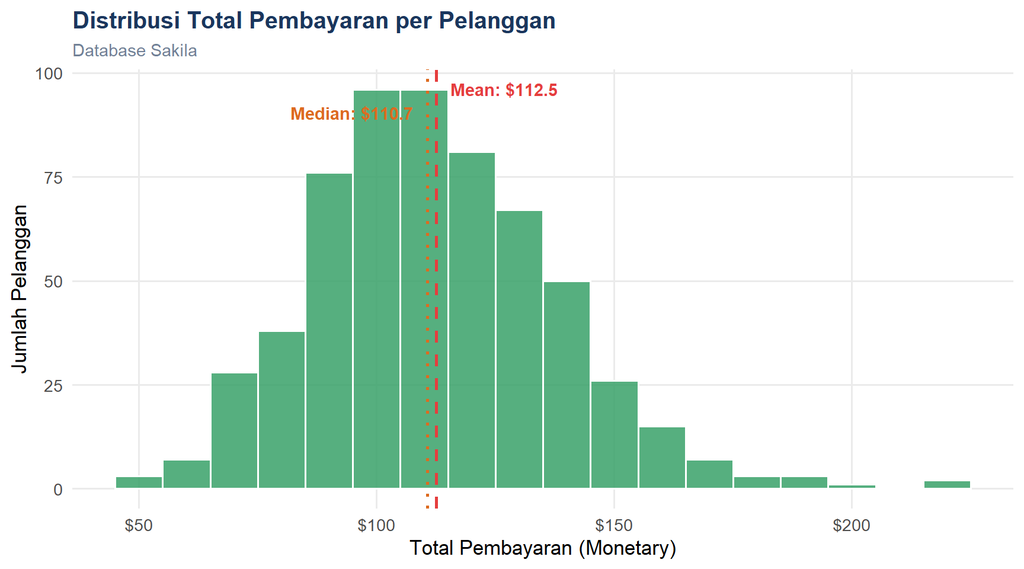

Distribusi Total Pembayaran per Pelanggan

```r
ggplot(data_rfm, aes(x = monetary)) +
  geom_histogram(binwidth = 10, fill = "#38a169", color = "#fff", alpha = 0.85) +
  geom_vline(xintercept = mean(data_rfm$monetary),
             color = "#e53e3e", linetype = "dashed", linewidth = 1) +
  geom_vline(xintercept = median(data_rfm$monetary),
             color = "#dd6b20", linetype = "dotted", linewidth = 1) +
  annotate("text",
           x = mean(data_rfm$monetary) + 3, y = Inf,
           label = paste0("Mean: $", round(mean(data_rfm$monetary), 1)),
           vjust = 2, hjust = 0, color = "#e53e3e", size = 3.8, fontface = "bold") +
  annotate("text",
           x = median(data_rfm$monetary) - 3, y = Inf,
           label = paste0("Median: $", round(median(data_rfm$monetary), 1)),
           vjust = 3.8, hjust = 1, color = "#dd6b20", size = 3.8, fontface = "bold") +
  scale_x_continuous(labels = dollar_format(prefix = "$")) +
  labs(
    title    = "Distribusi Total Pembayaran per Pelanggan",
    subtitle = "Database Sakila",
    x        = "Total Pembayaran (Monetary)",
    y        = "Jumlah Pelanggan"
  ) +
  theme_minimal(base_size = 13) +
  theme(
    plot.title       = element_text(face = "bold", color = "#1a365d", size = 15),
    plot.subtitle    = element_text(color = "#718096", size = 11),
    panel.grid.minor = element_blank()
  )
```

#### Interpretasi

Distribusi total pembayaran per pelanggan juga cenderung simetris dan mendekati distribusi normal. Garis merah menunjukkan nilai rata-rata (*mean*) dan garis oranye menunjukkan nilai median. Kedekatan nilai mean dan median mengindikasikan bahwa distribusi tidak terlalu *skewed* (condong), artinya tidak ada dominasi ekstrem dari kelompok pelanggan tertentu.

Terdapat sebagian kecil pelanggan dengan total pembayaran sangat tinggi yang merupakan segmen pelanggan paling berharga (*high-value customers*) bagi perusahaan rental.

### Visualisasi 3 — Top 20 Pelanggan dengan Total Pembayaran Tertinggi

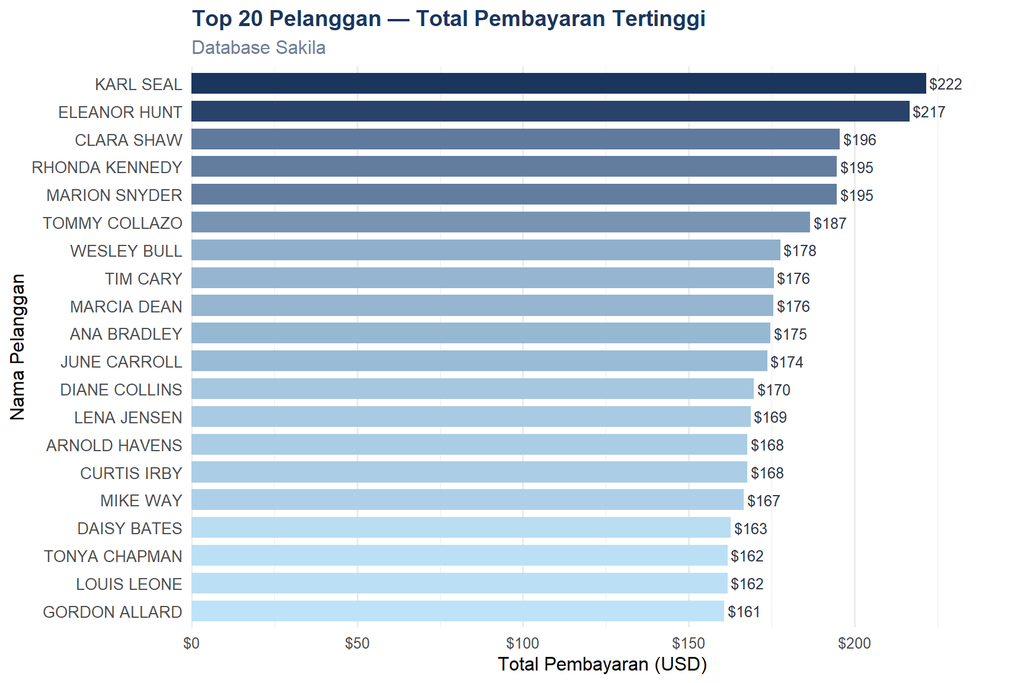

Top 20 Pelanggan Berdasarkan Total Pembayaran

```r
ggplot(data_top20,
       aes(x = reorder(nama_pelanggan, total_bayar),
           y = total_bayar,
           fill = total_bayar)) +
  geom_col(show.legend = FALSE, width = 0.75) +
  geom_text(aes(label = paste0("$", round(total_bayar, 0))),
            hjust = -0.1, size = 3.4, color = "#2d3748") +
  coord_flip() +
  scale_fill_gradient(low = "#bee3f8", high = "#1a365d") +
  scale_y_continuous(labels = dollar_format(),
                     expand = expansion(mult = c(0, .12))) +
  labs(
    title    = "Top 20 Pelanggan — Total Pembayaran Tertinggi",
    subtitle = "Database Sakila",
    x        = "Nama Pelanggan",
    y        = "Total Pembayaran (USD)"
  ) +
  theme_minimal(base_size = 12) +
  theme(
    plot.title         = element_text(face = "bold", color = "#1a365d", size = 14),
    plot.subtitle      = element_text(color = "#718096"),
    axis.text.y        = element_text(size = 10),
    panel.grid.major.y = element_blank()
  )
```

#### Interpretasi

Grafik batang horizontal di atas menampilkan 20 pelanggan dengan total pembayaran tertinggi. Gradasi warna dari biru muda ke biru tua mempermudah pembacaan peringkat nilai pelanggan.

Pelanggan teratas merupakan kontributor pendapatan paling signifikan bagi bisnis rental film. Identifikasi pelanggan *high-value* ini penting untuk strategi retensi pelanggan, misalnya melalui program loyalitas, penawaran eksklusif, atau layanan prioritas yang dapat memperpanjang hubungan bisnis dengan segmen pelanggan paling menguntungkan tersebut.

### Visualisasi 4 — Pola Rental Bulanan

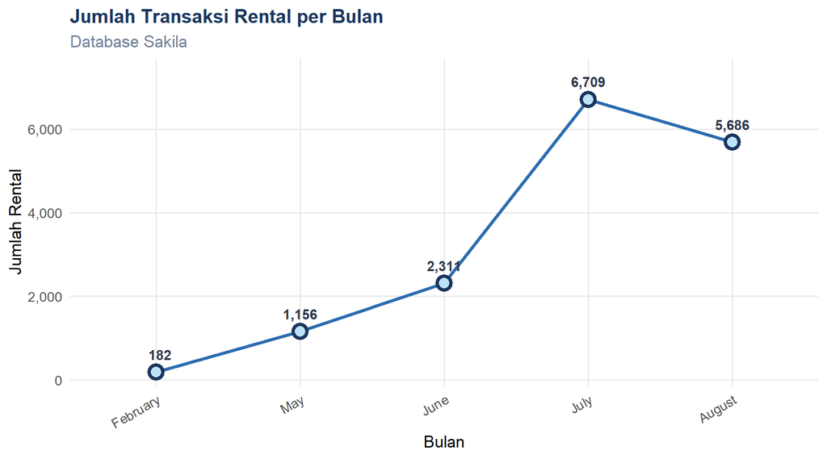

Jumlah Transaksi Rental per Bulan

```r
# Urutkan faktor bulan sesuai urutan kalender
data_bulan$bulan <- factor(data_bulan$bulan,
                           levels = data_bulan$bulan[order(data_bulan$no_bulan)])

ggplot(data_bulan, aes(x = bulan, y = total_rental, group = 1)) +
  geom_line(color = "#2b6cb0", linewidth = 1.4) +
  geom_point(color = "#1a365d", size = 4, shape = 21,
             fill = "#bee3f8", stroke = 2) +
  geom_text(aes(label = format(total_rental, big.mark = ",")),
            vjust = -1.2, size = 3.8, color = "#2d3748", fontface = "bold") +
  scale_y_continuous(labels = comma,
                     expand = expansion(mult = c(.05, .15))) +
  labs(
    title    = "Jumlah Transaksi Rental per Bulan",
    subtitle = "Database Sakila",
    x        = "Bulan",
    y        = "Jumlah Rental"
  ) +
  theme_minimal(base_size = 13) +
  theme(
    plot.title       = element_text(face = "bold", color = "#1a365d", size = 15),
    plot.subtitle    = element_text(color = "#718096"),
    axis.text.x      = element_text(angle = 30, hjust = 1),
    panel.grid.minor = element_blank()
  )
```

#### Interpretasi

Grafik garis di atas memperlihatkan fluktuasi jumlah transaksi rental sepanjang bulan-bulan yang tercakup dalam data Sakila. Terlihat adanya puncak transaksi (*peak season*) pada bulan tertentu yang mengindikasikan periode permintaan tinggi. Informasi ini sangat berguna untuk manajemen inventori dan penjadwalan staf — pada bulan-bulan ramai, ketersediaan stok film dan tenaga kerja perlu ditingkatkan.

Sebaliknya, bulan dengan jumlah rental rendah merupakan peluang untuk merancang kampanye promosi guna mendorong peningkatan transaksi di luar periode puncak.

### Visualisasi 5 — Pola Rental per Hari dalam Seminggu

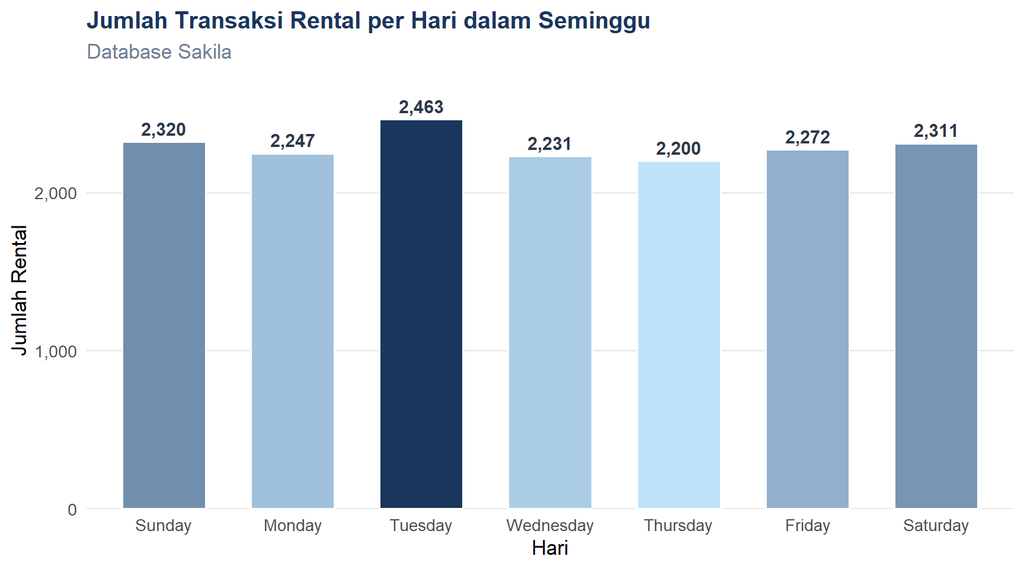

Jumlah Transaksi Rental per Hari dalam Seminggu

```r
urutan_hari <- c("Sunday","Monday","Tuesday","Wednesday","Thursday","Friday","Saturday")
data_hari$hari <- factor(data_hari$hari, levels = urutan_hari)

ggplot(data_hari, aes(x = hari, y = total_rental, fill = total_rental)) +
  geom_col(show.legend = FALSE, width = 0.65, color = "white") +

  geom_text(aes(label = format(total_rental, big.mark = ",")),
            vjust = -0.5, size = 4, fontface = "bold", color = "#2d3748") +
  scale_fill_gradient(low = "#bee3f8", high = "#1a365d") +
  scale_y_continuous(labels = comma,
                     expand = expansion(mult = c(0, .12))) +
  labs(
    title    = "Jumlah Transaksi Rental per Hari dalam Seminggu",
    subtitle = "Database Sakila",
    x        = "Hari",
    y        = "Jumlah Rental"
  ) +
  theme_minimal(base_size = 13) +
  theme(
    plot.title         = element_text(face = "bold", color = "#1a365d", size = 15),
    plot.subtitle      = element_text(color = "#718096"),
    panel.grid.major.x = element_blank(),
    panel.grid.minor   = element_blank()
  )
```

#### Interpretasi

Grafik batang di atas menampilkan distribusi jumlah transaksi rental berdasarkan hari dalam seminggu. Perbedaan tinggi batang antar hari memberikan gambaran mengenai hari-hari mana yang paling aktif dalam hal penyewaan film.

### Visualisasi 6 — Scatter Plot: Frekuensi Rental vs Total Pembayaran

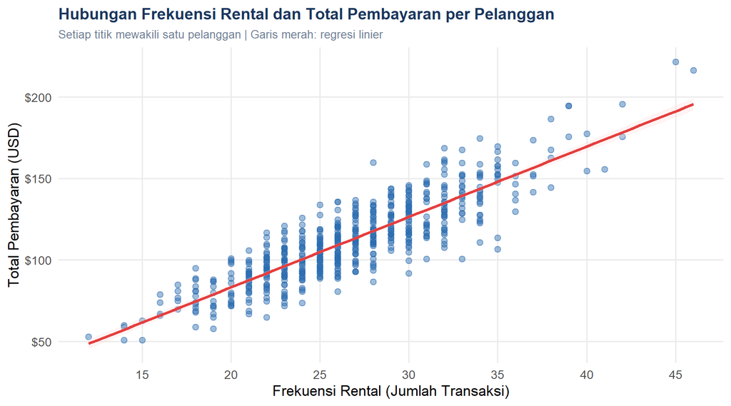

Hubungan Frekuensi Rental dan Total Pembayaran per Pelanggan

```r
ggplot(data_rfm, aes(x = frequency, y = monetary)) +
  geom_point(alpha = 0.45, color = "#2b6cb0", size = 2.2) +
  geom_smooth(method = "lm", se = TRUE,
              color = "#e53e3e", linetype = "solid", linewidth = 1.2,
              fill = "#fed7d7", alpha = 0.3) +
  scale_x_continuous(breaks = seq(0, 50, 5)) +
  scale_y_continuous(labels = dollar_format()) +
  labs(
    title    = "Hubungan Frekuensi Rental dan Total Pembayaran per Pelanggan",
    subtitle = "Setiap titik mewakili satu pelanggan | Garis merah: regresi linier",
    x        = "Frekuensi Rental (Jumlah Transaksi)",
    y        = "Total Pembayaran (USD)"
  ) +
  theme_minimal(base_size = 13) +
  theme(
    plot.title       = element_text(face = "bold", color = "#1a365d", size = 14),
    plot.subtitle    = element_text(color = "#718096", size = 10),
    panel.grid.minor = element_blank()
  )
```

#### Interpretasi

Scatter plot di atas memperlihatkan hubungan antara frekuensi rental (sumbu X) dan total pembayaran (sumbu Y) per pelanggan. Garis regresi linier berwarna merah beserta interval kepercayaan (*shaded area*) memperlihatkan arah dan kekuatan hubungan kedua variabel.

Pola sebaran titik yang membentuk tren naik dari kiri bawah ke kanan atas mengindikasikan adanya **hubungan positif**: pelanggan yang lebih sering menyewa film cenderung membayar lebih banyak secara total. Hal ini wajar secara logika bisnis dan menguatkan relevansi penggunaan frekuensi rental sebagai indikator nilai pelanggan.

## Analisis Statistika

### 1. Uji Korelasi Pearson

Korelasi Pearson digunakan untuk mengukur kekuatan dan arah hubungan **linear** antara dua variabel numerik. Rumusnya adalah:

$$r = \frac{\sum_{i=1}^{n}(x_i - \bar{x})(y_i - \bar{y})}
{\sqrt{\sum_{i=1}^{n}(x_i - \bar{x})^2 \cdot \sum_{i=1}^{n}(y_i
- \bar{y})^2}}$$

dengan $r \in [-1, 1]$. Semakin mendekati $\pm 1$, semakin kuat hubungan liniernya.

Interpretasi kekuatan korelasi mengacu pada panduan umum:

| Nilai $\|r\|$ | Kekuatan Korelasi |
| --- | --- |
| 0.00 – 0.19 | Sangat lemah |
| 0.20 – 0.39 | Lemah |
| 0.40 – 0.59 | Sedang |
| 0.60 – 0.79 | Kuat |
| 0.80 – 1.00 | Sangat kuat |

```r
r_pearson <- cor(data_rfm$frequency, data_rfm$monetary, method = "pearson")
cat("Korelasi Pearson (Frequency vs Monetary):", round(r_pearson, 6), "\n")
```

```
## Korelasi Pearson (Frequency vs Monetary): 0.870664
```

```r
# Uji signifikansi korelasi
uji_cor <- cor.test(data_rfm$frequency, data_rfm$monetary, method = "pearson")
print(uji_cor)
```

```
##
##  Pearson's product-moment correlation
##
## data:  data_rfm$frequency and data_rfm$monetary
## t = 43.249, df = 597, p-value < 2.2e-16
## alternative hypothesis: true correlation is not equal to 0
## 95 percent confidence interval:
##  0.8498282 0.8887826
## sample estimates:
##      cor
## 0.870664
```

#### Interpretasi Korelasi

Hasil menunjukkan nilai korelasi Pearson yang **sangat kuat dan positif** antara frekuensi rental dan total pembayaran. Nilai $p$-value yang jauh di bawah 0.05 membuktikan bahwa hubungan ini **signifikan secara statistik**.

Dengan demikian, dapat disimpulkan bahwa **frekuensi rental merupakan prediktor yang andal terhadap nilai moneter pelanggan** — pelanggan yang lebih rajin menyewa secara konsisten memberikan kontribusi pendapatan yang lebih besar.

### 2. Analisis Regresi Linier Sederhana

Regresi linier sederhana digunakan untuk memodelkan hubungan antara frekuensi rental ($X$) sebagai variabel independen dan total pembayaran ($Y$) sebagai variabel dependen.

Model regresi linier sederhana:

$$Y_i = \beta_0 + \beta_1 X_i + \varepsilon_i$$

di mana:

- $Y_i$ = total pembayaran pelanggan ke-$i$
- $X_i$ = frekuensi rental pelanggan ke-$i$
- $\beta_0$ = intercept (nilai $Y$ ketika $X = 0$)
- $\beta_1$ = koefisien regresi (kenaikan $Y$ per satu satuan kenaikan $X$)
- $\varepsilon_i$ = error/residual

Koefisien $\beta_1$ diestimasi menggunakan metode **Ordinary Least Squares (OLS)**:

$$\hat{\beta}_1 = \frac{\sum_{i=1}^{n}(x_i - \bar{x})(y_i -
\bar{y})}{\sum_{i=1}^{n}(x_i - \bar{x})^2}
\qquad , \qquad
\hat{\beta}_0 = \bar{y} - \hat{\beta}_1 \bar{x}$$

```r
model_reg <- lm(monetary ~ frequency, data = data_rfm)
summary(model_reg)
```

```
##
## Call:
## lm(formula = monetary ~ frequency, data = data_rfm)
##
## Residuals:
##     Min      1Q  Median      3Q     Max
## -41.386  -8.391  -0.074   8.431  41.936
##
## Coefficients:
##             Estimate Std. Error t value Pr(>|t|)
## (Intercept) -3.22174    2.72462  -1.182    0.237
## frequency    4.32164    0.09992  43.249   <2e-16 ***
## ---
## Signif. codes:  0 '***' 0.001 '**' 0.01 '*' 0.05 '.' 0.1 ' ' 1
##
## Residual standard error: 12.49 on 597 degrees of freedom
## Multiple R-squared:  0.7581, Adjusted R-squared:  0.7577
## F-statistic:  1871 on 1 and 597 DF,  p-value: < 2.2e-16
```

```r
beta0 <- coef(model_reg)[1]
beta1 <- coef(model_reg)[2]
r2    <- summary(model_reg)$r.squared

cat("=== Hasil Estimasi Model Regresi ===\n")
```

```
## === Hasil Estimasi Model Regresi ===
```

```r
cat(sprintf("Intercept (beta0)              : %.4f\n", beta0))
```

```
## Intercept (beta0)              : -3.2217
```

```r
cat(sprintf("Koef. Frequency (beta1)        : %.4f\n", beta1))
```

```
## Koef. Frequency (beta1)        : 4.3216
```

```r
cat(sprintf("R2 (Koefisien Determinasi)     : %.4f (%.2f%%)\n", r2, r2 * 100))
```

```
## R2 (Koefisien Determinasi)     : 0.7581 (75.81%)
```

#### Interpretasi Regresi Linier

Model regresi yang terbentuk dapat dituliskan sebagai:

$$\widehat{\text{Monetary}}_i = \hat{\beta}_0 + \hat{\beta}_1 \times
\text{Frequency}_i$$

- **Intercept** ($\hat{\beta}_0$): Nilai prediksi total pembayaran ketika frekuensi rental = 0. Meskipun secara praktis pelanggan dengan 0 rental tidak relevan, intercept tetap diperlukan sebagai konstanta model.
- **Koefisien Frequency** ($\hat{\beta}_1$): Setiap penambahan **1 transaksi rental** oleh seorang pelanggan diasosiasikan dengan kenaikan total pembayaran sebesar $\hat{\beta}_1$ USD. Nilai ini positif dan signifikan secara statistik, mengkonfirmasi hubungan searah.
- **R² (Koefisien Determinasi)**: Nilai $R^2$ menunjukkan bahwa sekitar $R^2 \times 100\%$ variasi total pembayaran pelanggan dapat dijelaskan oleh variasi frekuensi rental. Ini merupakan kemampuan prediksi yang sangat baik untuk model dengan satu variabel prediktor.

### 3. Segmentasi Pelanggan Berdasarkan RFM

Pelanggan dibagi ke dalam **tiga segmen** berdasarkan skor gabungan Frequency dan Monetary, menggunakan pendekatan kuartil:

$$\text{Skor RFM} = \frac{\text{Skor Frequency} + \text{Skor Monetary}}{2}$$

di mana skor masing-masing dihitung berdasarkan kuartil (1 = terendah, 3 = tertinggi).

```r
# Hitung batas kuartil (1/3 dan 2/3) untuk scoring
q_freq <- quantile(data_rfm$frequency, probs = c(1/3, 2/3))
q_mon  <- quantile(data_rfm$monetary,  probs = c(1/3, 2/3))

data_rfm <- data_rfm %>%
  mutate(
    skor_freq = case_when(
      frequency <= q_freq[1] ~ 1,
      frequency <= q_freq[2] ~ 2,
      TRUE                   ~ 3
    ),
    skor_mon = case_when(
      monetary <= q_mon[1] ~ 1,
      monetary <= q_mon[2] ~ 2,
      TRUE                 ~ 3
    ),
    skor_fm = (skor_freq + skor_mon) / 2,
    segmen  = case_when(
      skor_fm >= 2.5 ~ "High Value",
      skor_fm >= 1.5 ~ "Mid Value",
      TRUE           ~ "Low Value"
    )
  )

# Rangkuman jumlah pelanggan per segmen
tabel_segmen <- data_rfm %>%
  group_by(segmen) %>%
  summarise(
    jumlah_pelanggan = n(),
    rata_frequency   = round(mean(frequency), 1),
    rata_monetary    = round(mean(monetary),  2),
    .groups = "drop"
  ) %>%
  arrange(desc(rata_monetary))

tabel_segmen
```

```
## # A tibble: 3 × 4
##   segmen     jumlah_pelanggan rata_frequency rata_monetary
##   <chr>                 <int>          <dbl>         <dbl>
## 1 High Value              230           31.7         137.
## 2 Mid Value               214           25.8         107
## 3 Low Value               155           20.9          84.0
```

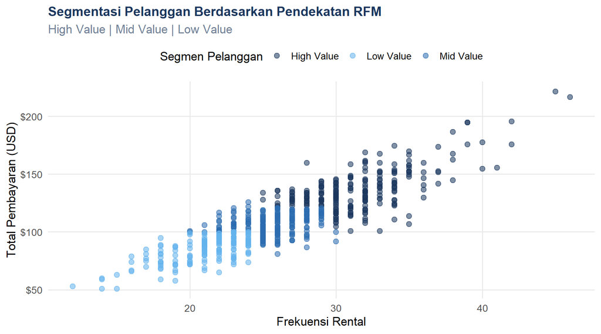

Distribusi Pelanggan per Segmen RFM

```r
warna_segmen <- c("High Value" = "#1a365d",
                  "Mid Value"  = "#2b6cb0",
                  "Low Value"  = "#63b3ed")

ggplot(data_rfm, aes(x = frequency, y = monetary, color = segmen)) +
  geom_point(alpha = 0.55, size = 2.4) +
  scale_color_manual(values = warna_segmen) +
  scale_y_continuous(labels = dollar_format()) +
  labs(
    title    = "Segmentasi Pelanggan Berdasarkan Pendekatan RFM",
    subtitle = "High Value | Mid Value | Low Value",
    x        = "Frekuensi Rental",
    y        = "Total Pembayaran (USD)",
    color    = "Segmen Pelanggan"
  ) +
  theme_minimal(base_size = 13) +
  theme(
    plot.title       = element_text(face = "bold", color = "#1a365d", size = 14),
    plot.subtitle    = element_text(color = "#718096"),
    legend.position  = "top",
    panel.grid.minor = element_blank()
  )
```

#### Interpretasi Segmentasi RFM

Segmentasi pelanggan menggunakan pendekatan RFM (Frequency + Monetary) menghasilkan tiga kelompok:

- **High Value**: Pelanggan dengan frekuensi rental tinggi dan total pembayaran besar. Segmen ini merupakan aset terpenting bagi bisnis. Program retensi dan loyalitas sebaiknya diprioritaskan untuk kelompok ini.
- **Mid Value**: Pelanggan dengan aktivitas menengah. Segmen ini memiliki potensi untuk ditingkatkan ke kategori *High Value* melalui insentif tambahan seperti diskon atau rekomendasi film yang dipersonalisasi.
- **Low Value**: Pelanggan dengan aktivitas rendah. Strategi re-engagement seperti penawaran promosi waktu terbatas atau komunikasi pemasaran yang lebih sering dapat diterapkan untuk mengaktifkan kembali segmen ini.

## Ringkasan Hasil Analisis

```r
ringkasan <- data.frame(
  Analisis = c(
    "Korelasi Pearson (Freq vs Monetary)",
    "Regresi Linier (R2)",
    "Segmen High Value",
    "Segmen Mid Value",
    "Segmen Low Value"
  ),
  Hasil = c(
    paste0("r = ", round(r_pearson, 4), " (Sangat kuat, positif)"),
    paste0("R2 = ", round(r2, 4), " (", round(r2 * 100, 1), "% variansi dijelaskan)"),
    paste0(tabel_segmen$jumlah_pelanggan[tabel_segmen$segmen == "High Value"],
           " pelanggan | Avg $",
           tabel_segmen$rata_monetary[tabel_segmen$segmen == "High Value"]),
    paste0(tabel_segmen$jumlah_pelanggan[tabel_segmen$segmen == "Mid Value"],
           " pelanggan | Avg $",
           tabel_segmen$rata_monetary[tabel_segmen$segmen == "Mid Value"]),
    paste0(tabel_segmen$jumlah_pelanggan[tabel_segmen$segmen == "Low Value"],
           " pelanggan | Avg $",
           tabel_segmen$rata_monetary[tabel_segmen$segmen == "Low Value"])
  )
)

kable(ringkasan, col.names = c("Analisis", "Hasil"),
      caption = "Ringkasan Hasil Analisis Perilaku Pelanggan — Database Sakila") %>%
  kable_styling(bootstrap_options = c("striped", "hover", "condensed"),
                full_width = TRUE) %>%
  column_spec(1, bold = TRUE, color = "#1a365d")
```

Ringkasan Hasil Analisis Perilaku Pelanggan — Database Sakila

| Analisis | Hasil |
| --- | --- |
| Korelasi Pearson (Freq vs Monetary) | r = 0.8707 (Sangat kuat, positif) |
| Regresi Linier (R2) | R2 = 0.7581 (75.8% variansi dijelaskan) |
| Segmen High Value | 230 pelanggan &#124; Avg $136.92 |
| Segmen Mid Value | 214 pelanggan &#124; Avg $107 |
| Segmen Low Value | 155 pelanggan &#124; Avg $83.97 |

## Kesimpulan

Berdasarkan seluruh rangkaian analisis yang telah dilakukan terhadap data pelanggan dalam database Sakila, diperoleh beberapa kesimpulan penting:

1. **Frekuensi rental dan total pembayaran memiliki hubungan yang sangat kuat dan positif.** Hal ini dibuktikan oleh nilai korelasi Pearson yang tinggi dan signifikan secara statistik. Semakin sering seorang pelanggan menyewa film, semakin besar total pembayaran yang diberikannya kepada perusahaan rental.
2. **Model regresi linier mampu menjelaskan sebagian besar variasi total pembayaran** hanya dengan menggunakan frekuensi rental sebagai prediktor tunggal, ditunjukkan oleh nilai $R^2$ yang tinggi.
3. **Segmentasi RFM mengidentifikasi tiga kelompok pelanggan** dengan karakteristik yang berbeda. Segmen *High Value* adalah kelompok paling strategis dan perlu mendapat perhatian khusus dalam program retensi pelanggan.
4. **Terdapat pola temporal dalam transaksi rental** — baik secara bulanan maupun harian — yang dapat dimanfaatkan untuk perencanaan operasional dan kampanye promosi yang lebih tepat sasaran.
5. Secara keseluruhan, analisis berbasis data ini menunjukkan bahwa **manajemen hubungan pelanggan (CRM)** yang dibangun di atas segmentasi nilai pelanggan dapat membantu bisnis rental film mengalokasikan sumber daya secara lebih efisien dan meningkatkan pendapatan jangka panjang.

> **Catatan:** Analisis ini menggunakan data dari database Sakila versi 1.5 (© Oracle).